# CS1010S Tutor Hack

Andrew Chou

26 September 2021

# 1 Introduction

Midterms are right around the corner! I should spend more time revising. However, I still need to grade my students’ assignments. With limited data from coursemology.org, I try to find a pattern in my students’ submission time. Meanwhile, maybe I can find insights to give to my students.

# 2 Read data

Download data of my 13 students from coursemology.org

```r
library(tidyverse)
fp = "../data/coursemo.csv"
cs1010s <- read_csv(fp) %>% select(!Status)
```

Students’ names are anonymized to two letter abbreviations.

```
## # A tibble: 153 x 6
##    Name  Title                         Submitted           Grade   Max   EXP
##    <chr> <chr>                         <dttm>              <dbl> <dbl> <dbl>
##  1 WW    Mission 7: Rogue Train        2021-09-26 14:32:00  52      53   491
##  2 CZ    Mission 7: Rogue Train        2021-09-26 02:13:00  51      53   481
##  3 GX    Mission 7: Rogue Train        2021-09-25 15:33:00  53      53   500
##  4 VA    Mission 8: 3-station IPPT     2021-09-24 18:32:00  18      18   500
##  5 CY    Mission 8: 3-station IPPT     2021-09-24 15:21:00  17      18   472
##  6 LZ    Mission 3: More than Thrice   2021-09-24 14:54:00   7      10   280
##  7 VA    Side Quest 7.1: Lazy Susan    2021-09-23 15:48:00  14      14   250
##  8 LY    Mission 7: Rogue Train        2021-09-23 13:40:00  51      53   481
##  9 ZY    Mission 4: Curve Introduction 2021-09-23 13:28:00  10.5    13   323
## 10 ZY    Mission 3: More than Thrice   2021-09-23 13:14:00   9      10   360
## # ... with 143 more rows
```

# 3 Students’ statistics

Who submitted the most?

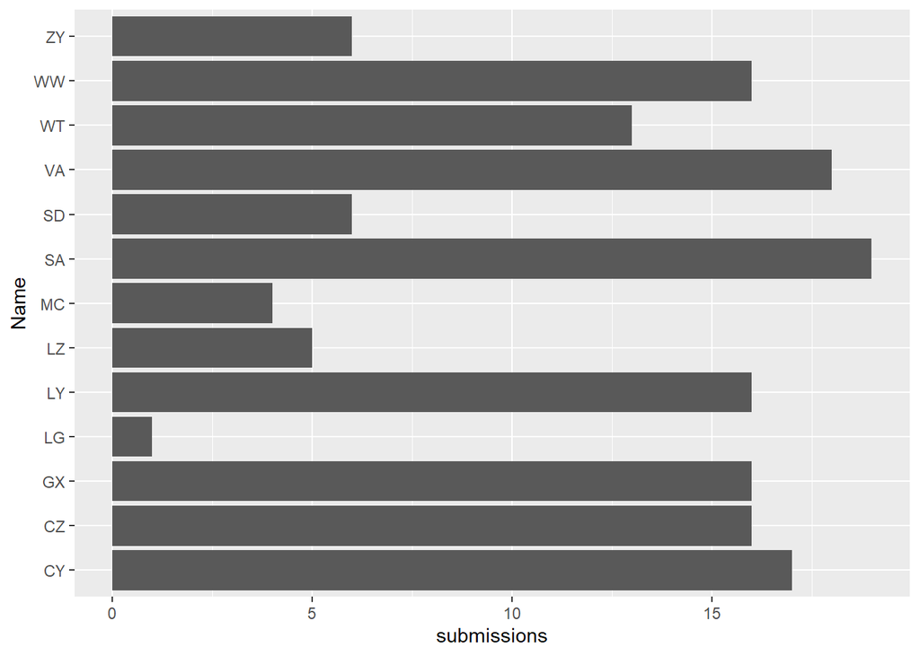

```r
submissions_data <- cs1010s %>% group_by(Name) %>% summarize(submissions = n(), total_exp = sum(EXP)) %>% arrange(desc(submissions))

ggplot(submissions_data, aes(x = Name, y = submissions)) + geom_bar(stat = "identity") + coord_flip()
```

SA, VA, and CY submitted 19, 18, and 17 homework respectively, while LG submitted only once.

Who gained the most EXP?

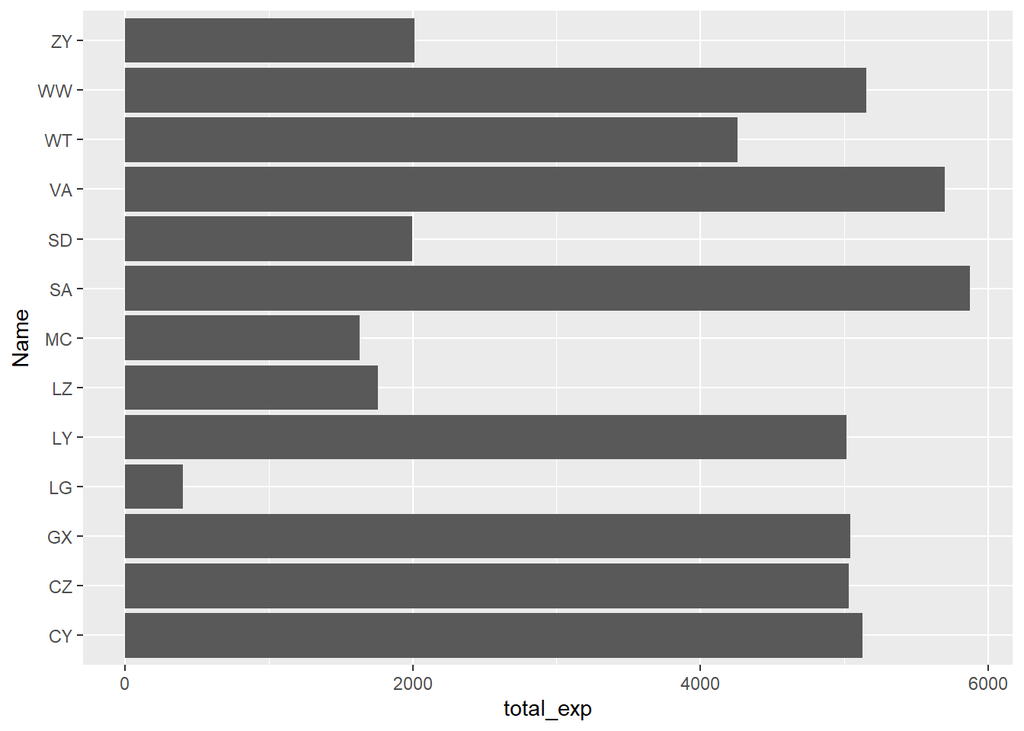

```r
ggplot(submissions_data, aes(x = Name, y = total_exp)) + geom_bar(stat = "identity") + coord_flip()
```

SA, VA, and WW gained the most EXP from homework, with five others not far behind.

What is the distribution of total EXP from homework?

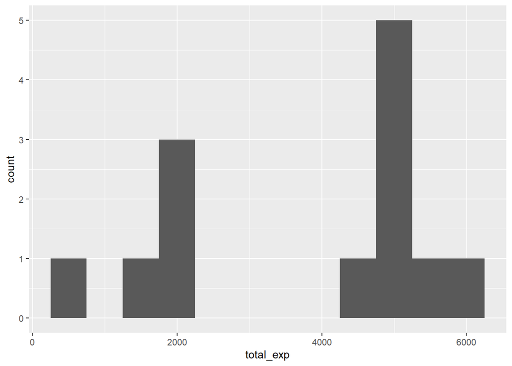

```r
ggplot(submissions_data, aes(x = total_exp)) + geom_histogram(binwidth = 500)
```

looks like five of my students are struggling with under 3000 EXP.

# 4 Students’ submission grades

Each assignment is graded. What are their average grades?

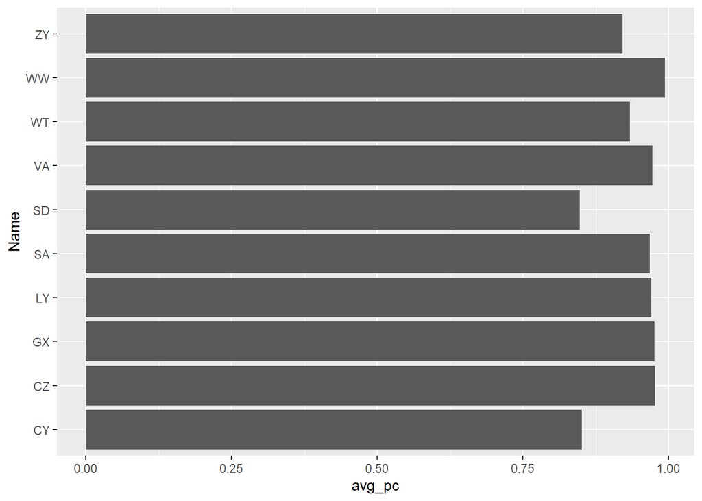

```r
cs1010s <- cs1010s %>% mutate(percentage = Grade / Max)

pct_data <- cs1010s %>% group_by(Name) %>% summarize(submissions = n(), total_exp = sum(EXP), avg_pc = mean(percentage)) %>% filter(submissions > 5)

ggplot(pct_data, aes(x = Name, y = avg_pc)) + geom_bar(stat = "identity") + coord_flip()
```

Excluding students who submitted less than six assignments, everyone’s average grade is higher than 80%. WW’s average is 99.4%, impressive!

Can we see their grades’ distributions?

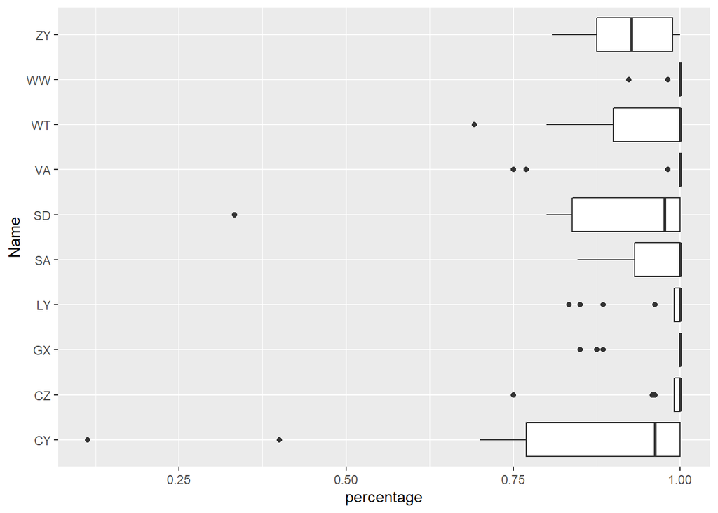

```r
ggplot(cs1010s %>% group_by(Name) %>% filter(n() > 5), aes(x = percentage, y = Name)) + geom_boxplot()
```

Excluding students who submitted less than six assignments, everyone (except for ZY, SD, and CY)’s median grade is 100%!

# 5 Students’ submitted time of day

I’m interested in the time of day when my students submit their homework:

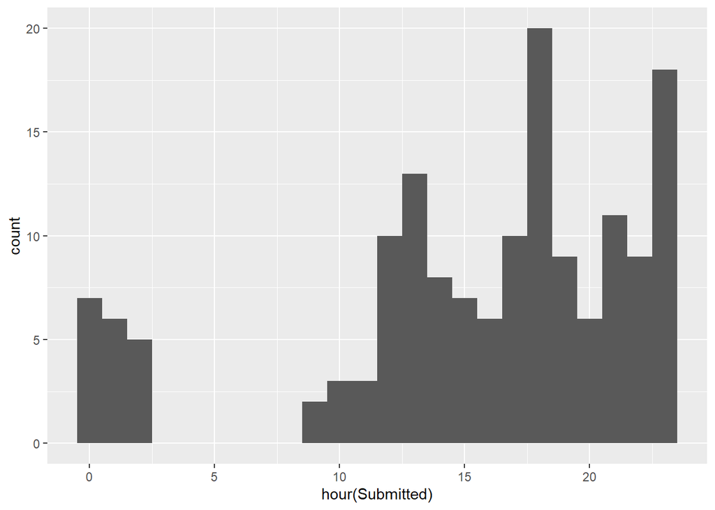

```r
hour <- function(dttm) {
  as.integer(format(dttm, format = "%H"))
}

ggplot(cs1010s, aes(x = hour(Submitted))) + geom_histogram(binwidth = 1)
```

The top 3 popular hour of day to submit is 18h, 23h, and 13h. It makes sense because they to submit so that they could go eat lunch/dinner, and 23h is just before the deadline. I’m surprised that 23h isn’t the most popular.

We can also produce one histogram for every student:

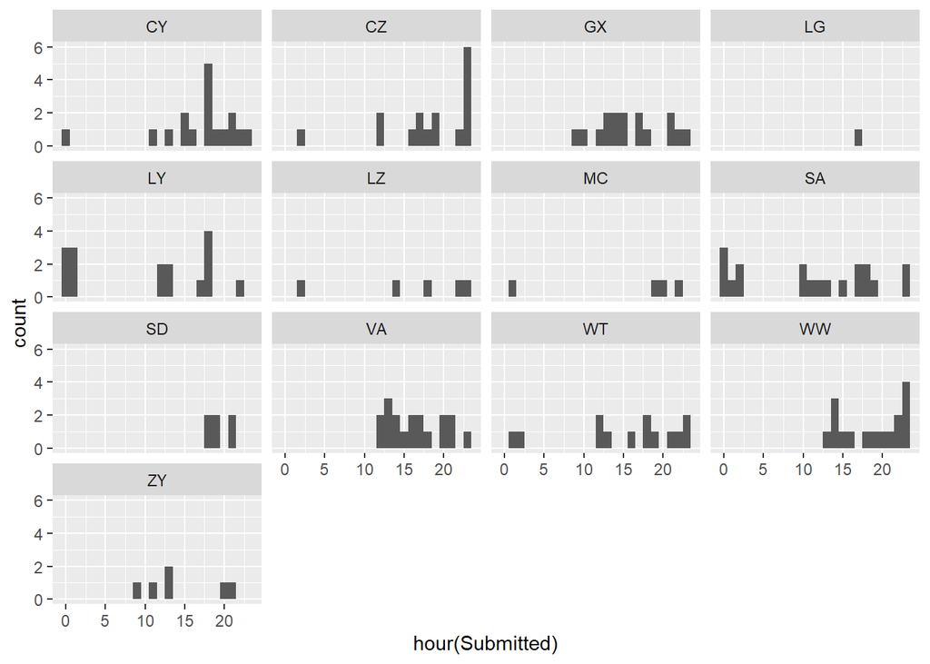

```r
ggplot(cs1010s, aes(x = hour(Submitted))) + geom_histogram(binwidth = 1) + facet_wrap(~Name)
```

I discovered that CZ and WW really like to submit at 23h, and CY and LY like to submit just before dinner. LY submitted more than one third of his assignments past midnight!

To account for times later than 2359, I used the Japanese extended hour system: 0 to 5 a.m. are called 24h to 29h in Japan.

```r
hour_ext <- function(dttm) {
  h <- as.integer(format(dttm, format = "%H"))
  m <- as.integer(format(dttm, format = "%M"))
  if(h < 7) {
    h <- h + 24
  }
  return(h + m / 60)
}

hour_ext <- Vectorize(hour_ext)
```

Let’s see if our function works.

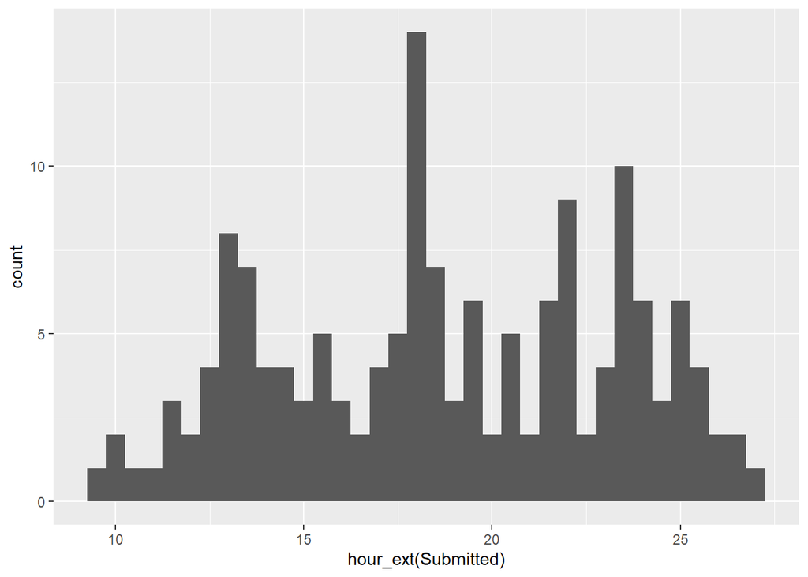

```r
ggplot(cs1010s, aes(x = hour_ext(Submitted))) + geom_histogram(binwidth = 0.5)
```

Nice. Now let’s see the student’s distribution as a box plot.

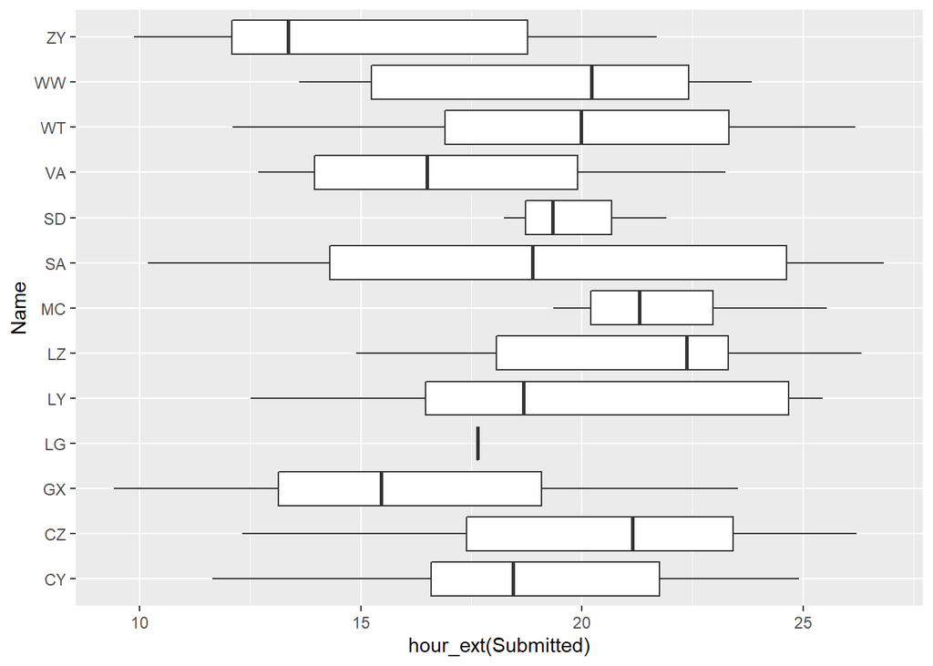

```r
ggplot(cs1010s, aes(x = hour_ext(Submitted), y = Name)) + geom_boxplot()
```

ZY submits her assignments the earliest in the day, with median around 13h, while LZ’s median being the latest, which is more than 22h. SA has the widest range, she could submit anytime from 10h to 27h.

# 6 Submission time vs grade

Does the submission time correlate with its accuracy?

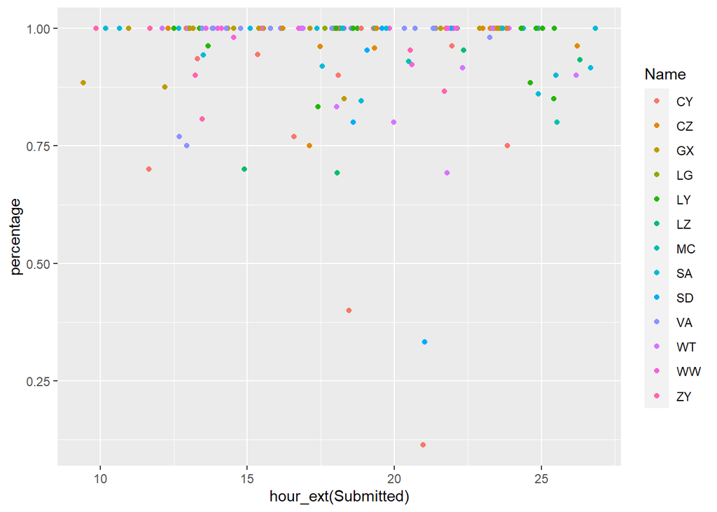

```r
ggplot(cs1010s, aes(x = hour_ext(Submitted), y = percentage, color = Name)) + geom_point()
```

```r
cs1010s <- cs1010s %>% mutate(h = hour(Submitted), h_e = hour_ext(Submitted))
```

Probably not. This is too messy, let’s try a boxplot instead.

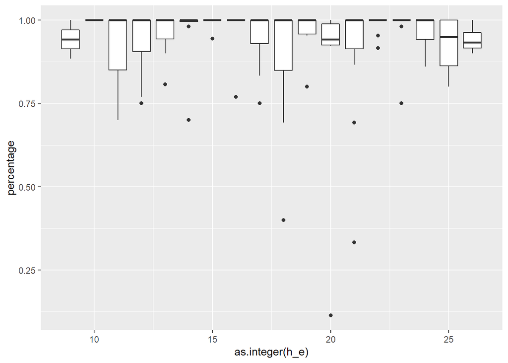

```r
ggplot(cs1010s, aes(x = as.integer(h_e), y = percentage, group = as.integer(h_e))) + geom_boxplot()
```

Wow, almost every hour’s median grade is 100%! The four exceptions are 09h, 20h, 25h, and 26h. Moral of the story: don’t code after midnight. (Or early in the morning)

Finally, a scatterplot of everyone’s lower quantile grade v.s. median submission time.

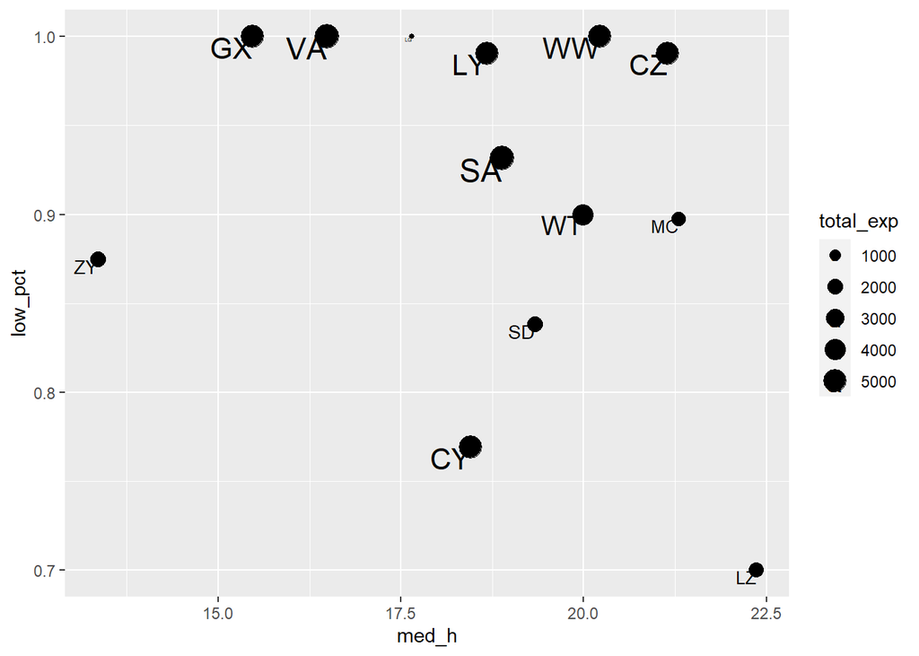

```r
acc_time <- cs1010s %>% group_by(Name) %>% summarize(med_h = median(h_e), low_pct = quantile(percentage, 0.25), total_exp = sum(EXP))

ggplot(acc_time, aes(x = med_h, y = low_pct, size = total_exp)) + geom_point() + geom_text(aes(label = Name),hjust = 1, vjust = 1)
```

# 7 Tutor’s takeway

When a student submits an assignment, he/she waits for some time for me to grade it. This period of time is called *grading time*. The average of grading time is ranked among all 55 tutors. My average grading time is currently 4 hours flat. However, that comes at a cost of visiting the website several times a day.

Moving on, I want to visit coursemology just *two times a day*. How do I minimize my average grading time, assuming the students’ habits remain constant?

```r
grading_time <- function(submt, grade) {
  ifelse(submt <= grade, grade - submt, grade + 24 - submt)
}

grading_time <- Vectorize(grading_time)

mean_gt <- function(timestamps, t1, t2) {
  gt1 <- grading_time(timestamps, t1)
  gt2 <- grading_time(timestamps, t2)
  return(mean(pmin(gt1, gt2)))
}
```

The function mean_gt calculates the mean grading time of all assignments if I check the website at t1 and t2 hours. For example:

```r
submission_times = cs1010s$h_e
mean_gt(submission_times, 12, 24)
```

```
## [1] 6.021242
```

This tells me that if I check everyday at noon and midnight, the students will have to wait 6.0 hours on average. I ran a loop to find the best time combinations, considering I wake up at 10h and go to sleep at 25h.

```r
time1 <- seq(10, 25, 0.1)
time2 <- seq(10, 25, 0.1)

min_gt <- 24
min_t  <- 0

for (i in time1) {
  for (j in time2) {
    gt <- mean_gt(submission_times, i, j)
    if (gt < min_gt) {
      min_gt <- gt
      min_t <- c(i, j)
    }
  }
}

min_gt
```

```
## [1] 4.196405
```

```r
min_t
```

```
## [1] 18.3 25.0
```

If I go grade the assignments at 18.3h and 25.0h, I’d expect my average grading time to be 4.20 hours. Not too bad!